# Project Work

```
                                                 Report
```

Welcome to the report. The report includes several sections. First, the given data was loaded and the variables were checked whether they matched with the provided documentation in 'Data Preperation' section of the report. Subsequently, the variables were explored with numerical and visual summaries and the data was cleaned out according to the obtained results. The data was modified a few times, and the reasons behind it were mentioned. In 'Data Exploration' section, the customer behaviours were examined. The data was explored to discover how the rental bikes were used during the trips. Important findings were recorded and some discoveries about the patterns of bike usage were made. In Hypothesis Testing section, the hypothesises proposed by the marketing and logistics teams were discussed and examined. Finally, a new hypothesis was introduced in 'Future Directions' part.

```
                                             DATA PREPERATION
```

```python
# Loading libraries
import pandas as pd
import matplotlib.pyplot as plt
import seaborn as sns
import numpy as numpy

# Loading data from a CSV file 'bikes.data' into a dataframe 'data'
data = pd.read_csv('C://Users/Comp-servis/Desktop/bikes.data')
# Displaying the data
data
```

|  | ticket | cost | month | location_from | location_to | duration | distance | assistance | energy_used | energy_collected |
| --- | --- | --- | --- | --- | --- | --- | --- | --- | --- | --- |
| 0 | single | 0.35 | 9 | MICROTEKNIA | PUIJONLAAKSO | 411.0 | 2150 | 1 | 19.0 | 2.7 |
| 1 | single | 1.20 | 5 | SATAMA | KEILANKANTA | 1411.0 | 7130 | 1 | 53.8 | 15.3 |
| 2 | savonia | 0.00 | 9 | TASAVALLANKATU | NEULAMÄKI | 1308.0 | 5420 | 1 | 43.0 | 9.9 |
| 3 | savonia | 0.00 | 10 | TORI | KAUPPAKATU | 1036.0 | 1180 | 1 | 6.5 | 2.1 |
| 4 | single | 0.30 | 9 | TORI | TORI | 319.0 | 1120 | 1 | 13.7 | 1.2 |
| ... | ... | ... | ... | ... | ... | ... | ... | ... | ... | ... |
| 1769 | savonia | 0.00 | 10 | KAUPPAKATU | TORI | 836.0 | 960 | 1 | 8.0 | 2.7 |
| 1770 | single | 0.20 | 7 | TORI | SATAMA | 199.0 | 930 | 1 | 3.7 | 3.6 |
| 1771 | season | 0.00 | 7 | TORI | TORI | 61.0 | 0 | 1 | 0.0 | 0.0 |
| 1772 | savonia | 0.00 | 9 | MICROTEKNIA | PUIJONLAAKSO | 610.0 | 2460 | 1 | 36.5 | 6.9 |
| 1773 | season | 0.00 | 8 | PUIJONLAAKSO | KAUPPAKATU | 478.0 | 2250 | 1 | 8.1 | 13.8 |

1774 rows × 10 columns

According to the data, the variables included in the dataframe are 'ticket', 'cost', 'month', 'location_from', 'location_to', 'duration', 'distance', 'assistance', 'energy_used' and 'energy_collected' which perfectly match the variables in the given documentation.

In order to filter out the data, it is really important to look for any irrevelant data, outliers, errors and missing values.

```python
# Getting a summary of the statistics for the numerical columns in the dataset
data.describe()
```

|  | cost | month | duration | distance | assistance | energy_used | energy_collected |
| --- | --- | --- | --- | --- | --- | --- | --- |
| count | 1774.000000 | 1774.000000 | 1774.000000 | 1774.000000 | 1774.000000 | 1774.000000 | 1774.000000 |
| mean | 0.491234 | 7.233371 | 671.323563 | 2460.067644 | 0.916009 | 17.399493 | 5.639290 |
| std | 4.127344 | 1.720351 | 1141.708627 | 2352.529305 | 0.277452 | 17.194463 | 6.379593 |
| min | 0.000000 | 4.000000 | 2.000000 | -3380.000000 | 0.000000 | 0.000000 | 0.000000 |
| 25% | 0.000000 | 6.000000 | 245.250000 | 910.000000 | 1.000000 | 1.425000 | 0.600000 |
| 50% | 0.050000 | 7.000000 | 546.500000 | 2030.000000 | 1.000000 | 14.350000 | 3.900000 |
| 75% | 0.550000 | 9.000000 | 877.750000 | 3605.000000 | 1.000000 | 26.900000 | 8.325000 |
| max | 100.000000 | 10.000000 | 25614.000000 | 20770.000000 | 1.000000 | 144.900000 | 56.400000 |

The above table gives a summary of the statistics for the numerical columns in the dataset. The minimum value for the 'energy_used' column is 0, which means that some customers did not ride the bike even though they rented it. This could be due to that there are some customers only trying out how bikes can be rented and cancelling the transaction without actually riding the bike. The numerical analysis for the distance raise some questions, since it includes values below zero.

The data can be better be understood with the use of visualisations.

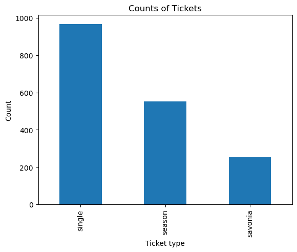

```
There are no any missing values.
```

```python
# Here, the data in the 'ticket' column is visually analyzed with a bar plot.

# A bar plot is generated according to the data in 'ticket'
data['ticket'].value_counts().plot(kind='bar')
# The title of the bar plot is set to 'Counts of Tickets'
plt.title('Counts of Tickets')
# The x axis is labelled as 'Ticket type'
plt.xlabel('Ticket type')

# The y axis is labelled as 'Count'
plt.ylabel('Count')

# Displaying the bar plot
plt.show()

# In the case of any missing values, the below parameter is equal to True
missing_values = data['ticket'].isna().any()

# If the parameter is True, then we will have a message of 'There is a missing value.', otherwise 'There are no any missing values.'
if missing_values:
    print("There is a missing value.")
else:
    print("There are no any missing values.")
```

According to the graph, there is no any irrevelant data. There are no missing values in the 'ticket' column. Thus, the data looks promising.

The next variable to be observed is 'month'. As the 'month' column includes numerical variables, the data will be analyzed with a histogram.

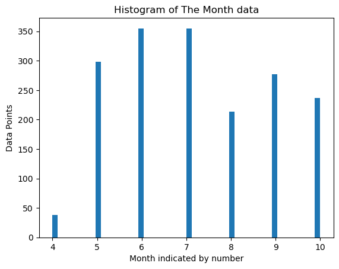

```
There are no any missing values.
```

```python
# Here, 'month' values are examined with the help of a histogram

# Selecting the 'month' column from the 'data' dataframe
month_data = data['month']

# Creating a histogram with an interval of 50
plt.hist(month_data, bins=50)

# Setting the name of the x-axis as 'Month indicated by number'
plt.xlabel('Month indicated by number')

# Setting the name of y-axis as 'Data Points'
plt.ylabel('Data Points')

# Setting the title as 'Histogram of The Month Data'
plt.title('Histogram of The Month data')

# Displaying the resultant histogram
plt.show()


# In the case of any missing values, the below parameter is equal to True
missing_values = data['month'].isna().any()

# If the parameter is True, then we will have a message of 'There is a missing value.', otherwise 'There are no any missing values.'
if missing_values:
    print("There is a missing value.")
else:
    print("There are no any missing values.")
```

All the values is in the range from 1 to 12, and the numbers are natural. According to our results, there are no any missing values and irrevelant data in the 'month' column in dataframe. Based on the results, it is reasonable to assume that customers mostly prefer the bikes as a primary way of transportation in May, June and July.

The duration data can be analyzed now. It is a numerical data, thus it can be examined with the means of a histogram and box pilot.

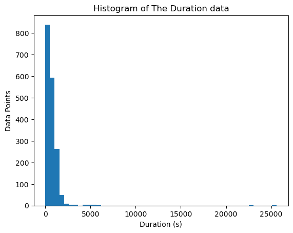

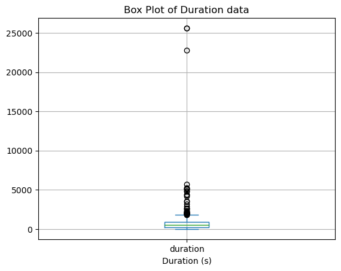

```
The mean duration of the electric bikes is 671.3235625704623 s
There are no any missing values.
```

```python
# Here, 'duration' values are examined visually

# Selecting the 'duration' column from the 'data' dataframe
duration_data = data['duration']

# Creating a histogram with an interval of 50
plt.hist(duration_data, bins=50)

# Setting the name of the x-axis as 'Duration (s)'
plt.xlabel('Duration (s)')

# Setting the name of y-axis as 'Data Points'
plt.ylabel('Data Points')

# Setting the title as 'Histogram of Duration Data'
plt.title('Histogram of The Duration data')

# Displaying the resultant histogram
plt.show()

# Creating a box plot for the 'duration' column in the 'data' dataframe.
data['duration'].plot(kind='box', grid=True)

# Seting the label for the x-axis to 'Duration (s)'
plt.xlabel('Duration (s)')

# Set the title of the plot to 'Box Plot of Duration data'
plt.title('Box Plot of Duration data')

# Displaying the resultant plot
plt.show()

# Printing the mean of the values in 'duration' column
print('The mean duration of the electric bikes is {} s'.format(data['duration'].mean()))

# In the case of any missing values, the below parameter is equal to True
missing_values = data['duration'].isna().any()

# If the parameter is True, then we will have a message of 'There is a missing value.', otherwise 'There are no any missing values.'
if missing_values:
    print("There is a missing value.")
else:
    print("There are no any missing values.")
```

The analysis of the graph for the data in 'duration' column shows that there is some irrevelant data. First of all, there are some outliers. These outliers should be removed, as the values are significantly higher than the other ones. The reason behind these outliers could be attributed to the malfunction of the measuring device. These values also should be removed as they do not meaningfully contribute to the data. Based on the results, there are no missing values in the 'duration' column.

```python
# Removing the values in duration which is more than 10000
data = data[data['duration']<15000]
data
# The index should be reset as the old index is still in use
data.reset_index(drop=True, inplace=True)
```

Subsequently, the data in the 'distance' column can be analyzed. The data should be only positive values, as we cannot have negative values on the distance. In order to analyze the data, a histogram and a box plot will be used.

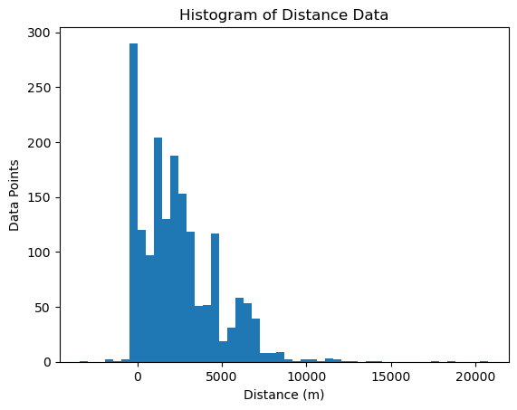

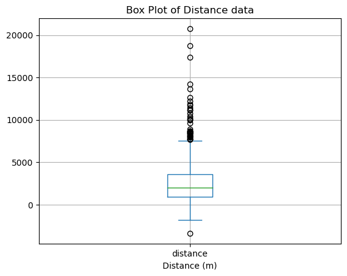

```
The mean distance travelled by the electric bikes is 2453.331451157538 m
There are no any missing values.
```

```python
# Here, the data in 'distance' column is visually analyzed with a histogram and box plot

# Selecting the 'distance' column from the 'data' dataframe
distance_data = data['distance']

# Creating a histogram with an interval of 50
plt.hist(distance_data, bins=50)

# Setting the name of the x-axis as 'Distance (m)'
plt.xlabel('Distance (m)')

# Setting the name of y-axis as 'Data Points'
plt.ylabel('Data Points')

# Setting the title as 'Histogram of Distance Data'
plt.title('Histogram of Distance Data')

# Displaying the resultant histogram
plt.show()

# Below code generates a box plot for the data in 'distance' column

# Creating a box plot for the 'distance' column in the 'data' dataframe.
data['distance'].plot(kind='box', grid=True)

# Seting the label for the x-axis to 'Distance (m)'
plt.xlabel('Distance (m)')

# Set the title of the plot to 'Box Plot of Distance data'
plt.title('Box Plot of Distance data')

# Displaying the resultant plot
plt.show()

# Printing the mean of the values in 'distance' column
print('The mean distance travelled by the electric bikes is {} m'.format(data['distance'].mean()))

# In the case of any missing values, the below parameter is equal to True
missing_values = data['distance'].isna().any()

# If the parameter is True, then we will have a message of 'There is a missing value.', otherwise 'There are no any missing values.'
if missing_values:
    print("There is a missing value.")
else:
    print("There are no any missing values.")
```

As can be seen from the results, the mean distance travelled by the electric bikes is nearly 2.5 km, which is really suprising. This value means that the customers prefer the electric bikes even they have to travel very long distances, signifying their trust in our product.

```python
# Removing outliers
data = data[data['distance'] < 15000]

# Converting negative values to their positive counterpart
data['distance'] = data['distance'].abs()

# Dropping the old index and setting the new one
data.reset_index(drop=True, inplace=True)
```

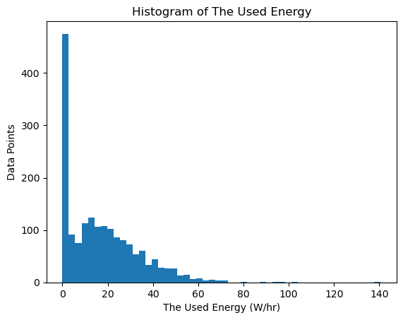

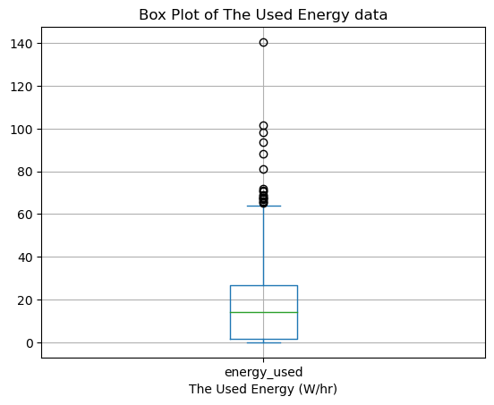

```
The mean value of the used energy 17.179242081447963 W/hr
There are no any missing values.
```

```python
# The code below examines the values in the 'energy_used' column.
# For this purpose, again a histogram and box plot will be used.

# Selecting the 'energy_used' column from the 'data' dataframe
energy_used_data = data['energy_used']

# Creating a histogram with an interval of 50
plt.hist(energy_used_data, bins=50)

# Setting the name of the x-axis as 'The Used Energy (W/hr)'
plt.xlabel('The Used Energy (W/hr)')

# Setting the name of y-axis as 'Data Points'
plt.ylabel('Data Points')

# Setting the title as 'Histogram of The Used Energy'
plt.title('Histogram of The Used Energy')

# Displaying the resultant histogram
plt.show()


# Below code generates a box plot for the data in 'energy_used' column

# Creating a box plot for the 'energy_used' column in the 'data' dataframe.
data['energy_used'].plot(kind='box', grid=True)

# Seting the label for the x-axis to 'The Used Energy (W/hr)'
plt.xlabel('The Used Energy (W/hr)')

# Set the title of the plot to 'Box Plot of The Used Energy data'
plt.title('Box Plot of The Used Energy data')

# Displaying the resultant plot
plt.show()

# Printing the mean of the values in 'energy_used' column
print('The mean value of the used energy {} W/hr'.format(data['energy_used'].mean()))

# In the case of any missing values, the below parameter is equal to True
missing_values = data['energy_used'].isna().any()

# If the parameter is True, then we will have a message of 'There is a missing value.', otherwise 'There are no any missing values.'
if missing_values:
    print("There is a missing value.")
else:
    print("There are no any missing values.")
```

Analysis of the data reveals that there are some outliers which can be kept to prevent the loss of important information. It should be also mentioned that the outliers are not extremely high values. No misssing values were observed in the 'energy_used' column. There are some cases in which, the used energy is equal to 0, I suggest to deal with these values after the examination of the values in the 'energy_collected' column.

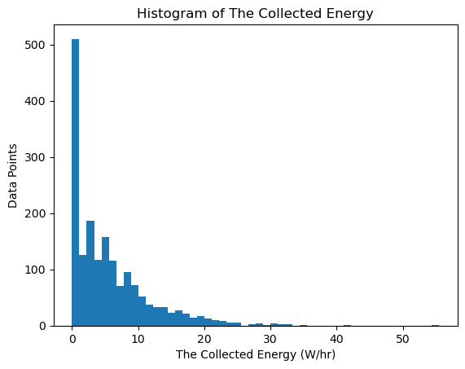

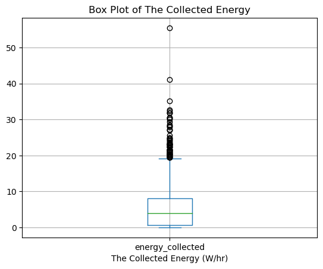

```
The mean cost of the paid fee by the customers is 5.5768099547511305 W/hr
There are no any missing values.
```

```python
# The code below examines the values in the 'energy_collected' columns.

# Below code generates a histogram for the data in 'energy_collected' column

# Selecting the 'energy_collected' column from the 'data' dataframe
energy_collected_data = data['energy_collected']

# Creating a histogram with an interval of 50
plt.hist(energy_collected_data, bins=50)

# Setting the name of the x-axis as 'The Collected Energy (W/hr)'
plt.xlabel('The Collected Energy (W/hr)')

# Setting the name of y-axis as 'Data Points'
plt.ylabel('Data Points')

# Setting the title as 'Histogram of The Collected Energy'
plt.title('Histogram of The Collected Energy')

# Displaying the resultant histogram
plt.show()

# Below code generates a box plot for the data in 'energy_collected' column

# Extracting data from 'energy_collected' column
x=data['energy_collected']

# Creating a range of values for the y-axis
y = range(len(x))


# Below code generates a box plot for the data in 'energy_collected' column

# Creating a box plot for the 'energy_collected' column in the 'data' dataframe. Set the figure size.
data['energy_collected'].plot(kind='box', grid=True)

# Seting the label for the x-axis to 'The Collected Energy (W/hr)'
plt.xlabel('The Collected Energy (W/hr)')

# Set the title of the plot to 'Box Plot of The Collected Energy data'
plt.title('Box Plot of The Collected Energy')

# Displaying the resultant plot
plt.show()

# Printing the mean of the values in 'energy_collected' column
print('The mean cost of the paid fee by the customers is {} W/hr'.format(data['energy_collected'].mean()))

# In the case of any missing values, the below parameter is equal to True
missing_values = data['energy_collected'].isna().any()

# If the parameter is True, then we will have a message of 'There is a missing value.', otherwise 'There are no any missing values.'
if missing_values:
    print("There is a missing value.")
else:
    print("There are no any missing values.")
```

There are notable outliers in the data, which are more than 50 W/hr. As there is a quite significant difference between this and the rest of the data, I suggest to remove this outlier. It should be also mentioned that there are some values that are equal to 0 in the collected energy data. This data could be the result of the case in which a customer tries to learn how to rent the bike without riding it. The rows in the dataframe that have the value of zero in all the 'energy_used', 'energy_collected' and 'distance' columns can be neglected, as they do not contribute to the data in a meaningful way.

```python
# Removing the outliers
data = data[data['energy_collected']<50]

# Removing the rows that have the value of zero simultaneously in all the 'energy_used', 'distance' and 'energy_collected' columns

data = data[~((data['energy_used'] == 0) & (data['energy_collected'] == 0) & (data['distance'] == 0))]

# Dropping the old index and setting the new one
data.reset_index(drop=True, inplace=True)
```

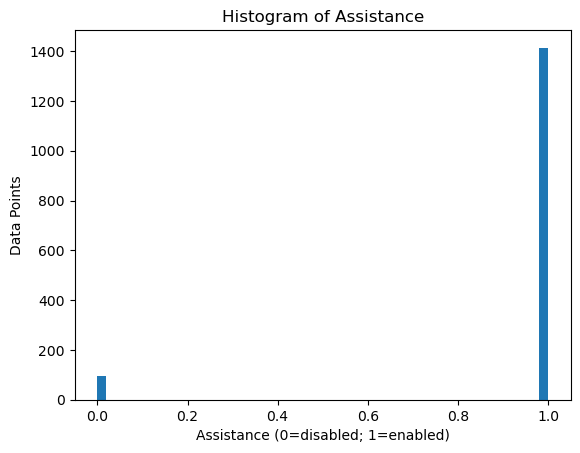

```
There are no any missing values.
```

```python
# The code below examines the values in the 'assistance' column.

# Selecting the 'assistance' column from the 'data' dataframe
assistance_data = data['assistance']

# Creating a histogram with an interval of 50
plt.hist(assistance_data, bins=50)

# Setting the name of the x-axis as 'Assistance (0=disabled; 1=enabled)'
plt.xlabel('Assistance (0=disabled; 1=enabled)')

# Setting the name of y-axis as 'Data Points'
plt.ylabel('Data Points')

# Setting the title as 'Histogram of Asssistance Data'
plt.title('Histogram of Assistance')

# Displaying the resultant histogram
plt.show()

# In the case of any missing values, the below parameter is equal to True
missing_values = data['assistance'].isna().any()

# If the parameter is True, then we will have a message of 'There is a missing value.', otherwise 'There are no any missing values.'
if missing_values:
    print("There is a missing value.")
else:
    print("There are no any missing values.")
```

As can be seen from the graph, the majority of values in the Assistance data is 1, which means that the customers generally preferred taking advantage of the electric assistance available in the bike. There is not any irrevelant data observed in the 'assistance' column.

The 'cost' data can be examined with the help of a histogram and box plot.

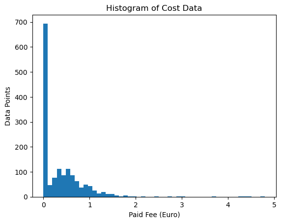

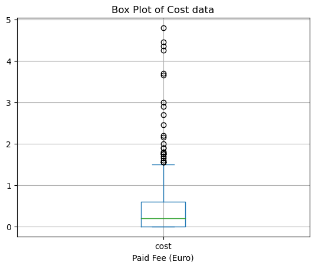

```
The mean cost of the paid fee by the customers is 0.35890728476821193
There are no any missing values.
```

```python
# The code below examines the values in the 'cost' column.

# Selecting the 'cost' column from the 'data' dataframe
cost_data = data['cost']

# Creating a histogram with an interval of 50
plt.hist(cost_data, bins=50)

# Setting the name of the x-axis as 'Paid Fee (Euro)'
plt.xlabel('Paid Fee (Euro)')

# Setting the name of y-axis as 'Data Points'
plt.ylabel('Data Points')

# Setting the title as 'Histogram of Cost Data'
plt.title('Histogram of Cost Data')

# Displaying the resultant histogram
plt.show()

# Below code generates a box plot for the data in 'cost' column

# Creating a box plot for the 'cost' column in the 'data' dataframe.
data['cost'].plot(kind='box', grid=True)

# Seting the label for the x-axis to 'Paid Fee (Euro)'
plt.xlabel('Paid Fee (Euro)')

# Set the title of the plot to 'Box Plot of Cost data'
plt.title('Box Plot of Cost data')

# Displaying the resultant plot
plt.show()

# Printing the mean of the values in 'cost' column
print('The mean cost of the paid fee by the customers is {}'.format(data['cost'].mean()))

# In the case of any missing values, the below parameter is equal to True
missing_values = data['cost'].isna().any()

# If the parameter is True, then we will have a message of 'There is a missing value.', otherwise 'There are no any missing values.'
if missing_values:
    print("There is a missing value.")
else:
    print("There are no any missing values.")
```

The analysis of the graph does not reveal any irrevelant data existent in the 'cost' column. According to the results, it can be said that very few customers are paying more than 2 euro. The mean of the cost is determined to be around 0.36 euro. There are also cost values which are equal to 0, which potentially suggest that there are some customers who applied for membership, which allow them to have free rides.

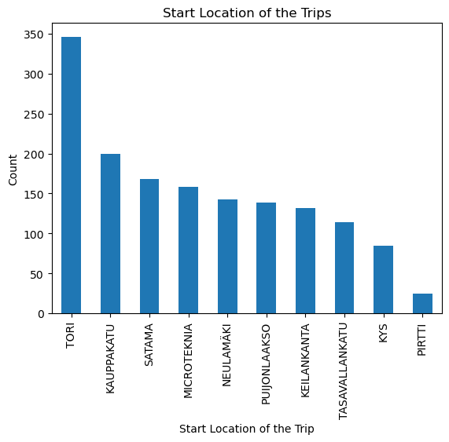

```
There are no any missing values.
```

```python
# The code below examines the values in the 'location_from' column.

# A bar plot is generated according to the data in 'location_from'
data['location_from'].value_counts().plot(kind='bar')
# The title of the bar plot is set to 'Start Location of the Trip'
plt.title('Start Location of the Trips')
# The x axis is labelled as 'Start Location of the Trip'
plt.xlabel('Start Location of the Trip')

# The y axis is labelled as 'Count'
plt.ylabel('Count')

# Displaying the bar plot
plt.show()

# In the case of any missing values, the below parameter is equal to True
missing_values = data['location_from'].isna().any()

# If the parameter is True, then we will have a message of 'There is a missing value.', otherwise 'There are no any missing values.'
if missing_values:
    print("There is a missing value.")
else:
    print("There are no any missing values.")
```

The analysis of data does not reveal any irrevelant data. No missing values were observed.

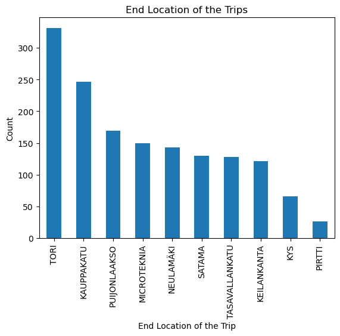

```
There are no any missing values.
```

```python
# The code below examines the values in the 'location_to' column.

# A bar plot is generated according to the data in 'location_to'
data['location_to'].value_counts().plot(kind='bar')
# The title of the bar plot is set to 'End Location of the Trips'
plt.title('End Location of the Trips')
# The x axis is labelled as 'Ticket type'
plt.xlabel('End Location of the Trip')

# The y axis is labelled as 'Count'
plt.ylabel('Count')

# Displaying the bar plot
plt.show()

# In the case of any missing values, the below parameter is equal to True
missing_values = data['location_to'].isna().any()

# If the parameter is True, then we will have a message of 'There is a missing value.', otherwise 'There are no any missing values.'
if missing_values:
    print("There is a missing value.")
else:
    print("There are no any missing values.")
```

The analysis of data does not reveal any irrevelant data. No missing values were observed.

In conclusion, major changes were done after examining the columns related to energy consumption and generation, while minor changes were performed through eliminating the outliers while analysing the duration and distance data. After the examination of all the variables, it can be said that an extensive exploratory data analysis is done to achieve a refined and high-quality dataset.

```
                                             DATA EXPLORATION
```

As can be seen from the data preperation section, our company sells three types of tickets, 'single', 'season' and 'savonia'. First, the 'single' ticket type will be examined.

```python
# Creating dataframe that only includes data from the 'single' ticket type
single_ticket_data = data[data['ticket'] == 'single']

# Calculating the number of trips made for the 'single' ticket type
number_of_trips = len(single_ticket_data)

# Calculating the total distance travelled for the 'single' ticket type
total_distance_travelled = single_ticket_data['distance'].sum()

# Calculating the total time travelled for the 'single' ticket type
total_time_travelled = single_ticket_data['duration'].sum()

#Calculating the total amount of fees paid for the 'single' ticket type
total_payment = single_ticket_data['cost'].sum()
# Displaying the results
print('The number of trips for the Single ticket type is {}'.format(number_of_trips))
print('The total distance travelled for the Single ticket type is {} m'.format(total_distance_travelled))
print('The total time travelled for the Single ticket type is {} s'.format(total_time_travelled))
print('The total amount of fees paid for the Single ticket type is {} euro'.format(total_payment))
print('\nThe average distance per trip for the Single ticket type is {} m'.format(total_distance_travelled/number_of_trips))
print('The average duration of the trip is {} s'.format(total_time_travelled/number_of_trips))
```

```
The number of trips for the Single ticket type is 822
The total distance travelled for the Single ticket type is 2491570 m
The total time travelled for the Single ticket type is 619052.0 s
The total amount of fees paid for the Single ticket type is 536.95 euro

The average distance per trip for the Single ticket type is 3031.1070559610707 m
The average duration of the trip is 753.1046228710462 s
```

```python
# Creating dataframe that only includes data from the 'season' ticket type
season_ticket_data = data[data['ticket'] == 'season']

# Calculating the number of trips made for the 'season' ticket type
number_of_trips = len(season_ticket_data)

# Calculating the total distance travelled for the 'season' ticket type
total_distance_travelled = season_ticket_data['distance'].sum()

# Calculating the total time travelled for the 'season' ticket type
total_time_travelled = season_ticket_data['duration'].sum()

#Calculating the total amount of fees paid for the 'season' ticket type
total_payment = season_ticket_data['cost'].sum()
# Displaying the results
print('The number of trips for the Season ticket type is {}'.format(number_of_trips))
print('The total distance travelled for the Season ticket type is {} m'.format(total_distance_travelled))
print('The total time travelled for the Season ticket type is {} s'.format(total_time_travelled))
print('The total amount of fees paid for the Season ticket type is {} euro'.format(total_payment))
print('\nThe average distance per trip for the Season ticket type is {} m'.format(total_distance_travelled/number_of_trips))
print('The average duration of the trip for the Season ticket type is {} s'.format(total_time_travelled/number_of_trips))
```

```
The number of trips for the Season ticket type is 465
The total distance travelled for the Season ticket type is 1315880 m
The total time travelled for the Season ticket type is 317402.0 s
The total amount of fees paid for the Season ticket type is 3.0 euro

The average distance per trip for the Season ticket type is 2829.8494623655915 m
The average duration of the trip for the Season ticket type is 682.5849462365592 s
```

```python
# Creating dataframe that only includes data from the 'savonia' ticket type
savonia_ticket_data = data[data['ticket'] == 'savonia']

# Calculating the number of trips made for the 'savonia' ticket type
number_of_trips = len(savonia_ticket_data)

# Calculating the total distance travelled for the 'savonia' ticket type
total_distance_travelled = savonia_ticket_data['distance'].sum()

# Calculating the total time travelled for the 'savonia' ticket type
total_time_travelled = savonia_ticket_data['duration'].sum()

#Calculating the total amount of fees paid for the 'savonia' ticket type
total_payment = savonia_ticket_data['cost'].sum()
# Displaying the results
print('The number of trips for the Savonia ticket type is {}'.format(number_of_trips))
print('The total distance travelled for the Savonia ticket type is {} m'.format(total_distance_travelled))
print('The total time travelled for the Savonia ticket type is {} s'.format(total_time_travelled))
print('The total amount of fees paid for the Savonia ticket type is {} euro'.format(total_payment))
print('\nThe average distance per trip for the Savonia ticket type is {} m'.format(total_distance_travelled/number_of_trips))
print('The average duration of the trip for the Savonia ticket type is {} s'.format(total_time_travelled/number_of_trips))
print(data)
```

```
The number of trips for the Savonia ticket type is 223
The total distance travelled for the Savonia ticket type is 495260 m
The total time travelled for the Savonia ticket type is 138548.0 s
The total amount of fees paid for the Savonia ticket type is 2.0 euro

The average distance per trip for the Savonia ticket type is 2220.896860986547 m
The average duration of the trip for the Savonia ticket type is 621.2914798206278 s
       ticket  cost  month   location_from   location_to  duration  distance  \
0      single  0.35      9     MICROTEKNIA  PUIJONLAAKSO     411.0      2150
1      single  1.20      5          SATAMA   KEILANKANTA    1411.0      7130
2     savonia  0.00      9  TASAVALLANKATU     NEULAMÄKI    1308.0      5420
3     savonia  0.00     10            TORI    KAUPPAKATU    1036.0      1180
4      single  0.30      9            TORI          TORI     319.0      1120
...       ...   ...    ...             ...           ...       ...       ...
1505   single  1.00      7     KEILANKANTA    KAUPPAKATU    1167.0      6070
1506  savonia  0.00     10      KAUPPAKATU          TORI     836.0       960
1507   single  0.20      7            TORI        SATAMA     199.0       930
1508  savonia  0.00      9     MICROTEKNIA  PUIJONLAAKSO     610.0      2460
1509   season  0.00      8    PUIJONLAAKSO    KAUPPAKATU     478.0      2250

      assistance  energy_used  energy_collected
0              1         19.0               2.7
1              1         53.8              15.3
2              1         43.0               9.9
3              1          6.5               2.1
4              1         13.7               1.2
...          ...          ...               ...
1505           1         34.3               3.0
1506           1          8.0               2.7
1507           1          3.7               3.6
1508           1         36.5               6.9
1509           1          8.1              13.8

[1510 rows x 10 columns]
```

All the required parameters are determined for each ticket type. Based on the results, the most popular ticket type is 'single' ticket type. The second is the seasonal ticket type, while the least preferred ticket type is 'Savonia'. The analysis of the average distance per trip for each ticket type reveals the fact that customers mainly prefer the 'single' ticket type for the longer trips. After having calculated the average duration of the trip for ticket type, it becomes clear that, the customers prefer 'single' ticket type, if they have to spend a lot of time on the road. The values for the average duration per the trip for 'savonia' and 'season' exhibit high degree of similarity. Looking at the generated revenue for the ticket types, it is evident that the 'single' ticket types had the most financial impact.

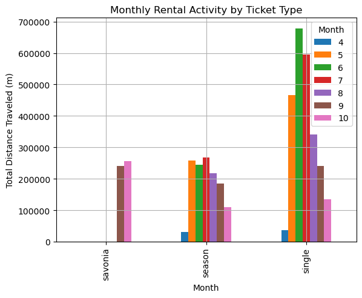

```python
# Grouping the data by 'ticket' and 'month' and calculating the sum of the distance for each combination
monthly_distance = data.groupby(['ticket', 'month'])['distance'].sum().unstack()

# Ploting the bar chart
monthly_distance.plot(kind='bar',grid=True)

# Setting the title to 'Monthly Rental Activity by Ticket Type'
plt.title('Monthly Rental Activity by Ticket Type')

# Setting the x-label as 'Month'
plt.xlabel('Month')

# Setting the y-label as 'Total Distance Traveled (m)'
plt.ylabel('Total Distance Traveled (m)')

# Setting the Legend as 'Month'
plt.legend(title='Month')

# Displaying the resultant bar chart
plt.show()
```

```python
# Creating a new DataFrame to calculate bike surplus at each station
bike_surplus_data = pd.DataFrame()

# Determining the number of bikes arriving at each station
arrived_bikes = data['location_to'].value_counts()

# Determining the number of bikes departing from each station
departed_bikes = data['location_from'].value_counts()

# Creating a 'Station' column with station names
bike_surplus_data['Station'] = arrived_bikes.index

# Creating a 'Arrived Bikes' column with the number of arrived bikes for each station
bike_surplus_data['Arrived Bikes'] = arrived_bikes.values

# Creating a 'Departed Bikes' column with the number of departed bikes for each station
bike_surplus_data['Departed Bikes'] = departed_bikes.values

# Calculating the bike surplus at each station which will be indicated at 'Surplus' column
bike_surplus_data['Surplus'] = bike_surplus_data['Arrived Bikes'] - bike_surplus_data['Departed Bikes']

# Sorting the dataframe based on the values in 'Surplus' column
sorted_bike_surplus_data = bike_surplus_data.sort_values(by='Surplus', ascending=False)

# Dropping the old index and setting the new one
sorted_bike_surplus_data.reset_index(drop=True, inplace=True)

# Displaying the bike results
print(sorted_bike_surplus_data)
```

```
          Station  Arrived Bikes  Departed Bikes  Surplus
0      KAUPPAKATU            246             200       46
1     KEILANKANTA            121             114        7
2    PUIJONLAAKSO            169             168        1
3          PIRTTI             26              25        1
4       NEULAMÄKI            143             143        0
5  TASAVALLANKATU            128             132       -4
6     MICROTEKNIA            150             158       -8
7          SATAMA            130             139       -9
8            TORI            331             346      -15
9             KYS             66              85      -19
```

```
The average energy recovery after trips is 32.38457320658242 %
```

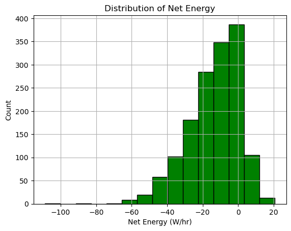

|  | Net Energy |
| --- | --- |
| count | 1510.000000 |
| mean | -13.556490 |
| std | 14.779062 |
| min | -108.800000 |
| 25% | -22.300000 |
| 50% | -11.700000 |
| 75% | -1.200000 |
| max | 20.700000 |

```python
# Creating a new DataFrame to calculate net energy gain
net_energy_data = pd.DataFrame()

# Calculating the net energy gain for each trip which will be indicated at 'Net Energy' column
net_energy_data['Net Energy'] = data['energy_collected'] - data['energy_used']

# Calculating the mean of the energy recovery
print('The average energy recovery after trips is {} %'.format(100*data['energy_collected'].mean()/data['energy_used'].mean()))

# Creating a histogram based on the data in 'Net Energy' column
plt.hist(net_energy_data['Net Energy'], bins=15, color='green', edgecolor='black')

# Setting the title as 'Distribution of Net Energy'
plt.title('Distribution of Net Energy')

# Setting the x-label as 'Net Energy (W/hr)'
plt.xlabel('Net Energy (W/hr)')

# Displaying the gridlines
plt.grid(True)

# Setting the y-label as 'Count'
plt.ylabel('Count')

# Dsiplaying the resultant histogram
plt.show()

net_energy_data.describe()
```

As can be seen from the results, the average energy recovery after the trips is around 32 %, which signifies the fact that the electric bikes possess low energy efficiency. As a suggestion, alternative battery options that could increase the ability of our bikes to capture and reuse the consumed energy should be sought. The average battery level after the trips is nearly -13.5 W/hr, which means that generally more energy is consumed during electric bike trips than is recovered. The maximum magnitudes of the net energy values is 20.7 W/hr, while the minimum is -108.8, being nearly 5 times more than the maxiumum.

```
                                          HYPOTHESiS TESTING
```

In this section of the report, various hypotheses suggested by the marketing and logistics teams will be tested by exploring supporting statistical evidence.

```python
import scipy

# In order to analyze the first hypothesis proposed from the marketing team, the data should be checked whether it is normally ditributed or not
# For this purpose, the Shapiro-Wilk test will be performed. If the returned p-values are less than < 0.05, it implies that the data is not normally distributed

# Selecting the data from the 'duration' column for 'single' tickets
single_ticket_durations = data[data['ticket'] == 'single']['duration']

# Selecting the data from the 'duration' column for 'season' tickets
season_ticket_durations = data[data['ticket'] == 'season']['duration']

#Displaying the result for the data from the 'duration' column for 'single' tickets
print(scipy.stats.shapiro(single_ticket_durations))

#Displaying the result for the data from the 'duration' column for 'season' tickets
print(scipy.stats.shapiro(season_ticket_durations))
```

```
ShapiroResult(statistic=0.7511749863624573, pvalue=2.2369457294766507e-33)
ShapiroResult(statistic=0.9607822299003601, pvalue=8.494552283799806e-10)
```

The p-values for both of the variables are less than 0.05, which means that the data is not normally distributed. Next, it should be checked whether the variables are paired or unpaired. The paired variables are dependent, while the unpaired ones are independent. The paired variables must have the same number of observations.

```python
# Displaying the number of observations for the single_ticket_durations
print(len(single_ticket_durations))

# Displaying the number of observations for the season_ticket_durations
print(len(season_ticket_durations))
```

```
822
465
```

It is clear that the variables do not have the same number of observations, which mean that the variables are unpaired. It can be concluded that we have two unpaired and not normally distributed variables. In order to explore the statistical evidence, Mann-Whitney test will be performed for two unpaired and not normally distributed variables.

Mann-Whitney test is a nonparametric test of the null hypothesis which is the likelihood of X being greater than Y is equal to the likelihood of Y being greater than X for randomly selected values X and Y from two variables.

```python
# Performing the Mann-Whitney test for the variables of single_ticket_durations and season_ticket_durations
scipy.stats.mannwhitneyu(single_ticket_durations,season_ticket_durations,\
use_continuity=True,alternative='two-sided')
```

```
MannwhitneyuResult(statistic=196860.5, pvalue=0.3697537944632039)
```

According to our results, p-value is more than 0.05, which means that there is not enough statistical evidence to reject the null hypothesis. Thus, the results do not give us sufficient evidence to conclude that there is a significant difference between the duration of the trips made with the 'single' and 'season' tickets. In conclusion, this hypothesis is not true. Based on the results it can be said that the customers who rent the bikes with 'single' and 'season' ticket types have similar trip durations while riding the electric bikes.

Now, the second hypothesis can be evaluated.

```python
# Again, the variables will go through the normalization test (Shapiro-Wilk)

#Displaying the result for the data from the 'distance' column
print(scipy.stats.shapiro(data['distance']))

#Displaying the result for the data from the 'energy_used' column
print(scipy.stats.shapiro(data['energy_used']))
```

```
ShapiroResult(statistic=0.9125925302505493, pvalue=1.249657338897022e-28)
ShapiroResult(statistic=0.925338625907898, pvalue=9.553843578581142e-27)
```

Both of the p-values for the variables are below than 0.05, which signifies the fact that these variables are not normally distributed. According to this finding, Spearman correlation test will be carried out instead of Pearson correlation test, as the latter is more suitable for the normally distributed values.

```python
# Performing the Spearman correlation test
scipy.stats.spearmanr(data['distance'],data['energy_used'])
```

```
SignificanceResult(statistic=0.8323012037172596, pvalue=0.0)
```

The resultant p-value is calculated to be approximately 0.0, which means that the null hypothesis can be rejected. According to our result, there is significant statistical evidence to claim that the travel distance positively correlates with the average rate at which electricity is consumed during the trip. Based on this statement, it can be concluded that the customers who use electric bikes for longer distances are likely to utilize more energy during their trips. This insight can be taken advantage of in the promotion of our product. For example, a longer battery life can be offered to the customers who travel long distances, encouraging them to use our bikes again. Now, the hypothesis proposed by the logistic team can be examined. The data for the 'ticket' and 'assistance' columns is categorical data, which means that we have two categorical variables to analyze. For this purpose, Pearson's chi-squared test will be performed.

```python
from scipy.stats import chi2_contingency

# Creating a contingency table
contingency_table = pd.crosstab(data['ticket'], data['assistance'])

# Displaying the resultant table
print(contingency_table)

# Performing Pearson's chi-squared test
print('\n{}'.format(chi2_contingency(contingency_table)))
```

```
assistance   0    1
ticket
savonia     30  193
season      17  448
single      49  773

Chi2ContingencyResult(statistic=24.77554690943019, pvalue=4.169253917969586e-06, dof=2, expected_freq=array([[ 14.17748344, 208.82251656],
       [ 29.56291391, 435.43708609],
       [ 52.25960265, 769.74039735]]))
```

According to the results, the p-value is less than 0.05, which means that the null hypothesis can be rejected. There is strong statistical evidence that 'savonia' ticket type in 'ticket' column differs from the others with respect to how often the electric assistance is used. Based on the result, it could be suggested that the customers who rent bikes with 'savonia' ticket type possess a distinct usage pattern of the electric assistance.

```
                                                FUTURE DIRECTIONS
```

I would like to suggest another worth exploring hypothesis that could offer insights into marketing opportunities and user experience. The hypothesis to explore is that if there is an important connection between the time of the year (month) and the total distance traveled by our customers. This is an important hypothesis, since this information could reveal seasonal patterns in bike rentals. If this hypothesis is true, we could appeal the customers who have to travel longer distances with targeted promotions or discounts to encourage bike rentals. The budget also can be allocated in a more efficient way by anticipating seasonal changes in demand.

```python
#Displaying the result for the data from the 'month' column
print(scipy.stats.shapiro(data['month']))

#Displaying the result for the data from the 'distance' column
print(scipy.stats.shapiro(data['distance']))
```

```
ShapiroResult(statistic=0.9205739498138428, pvalue=1.7743900726430706e-27)
ShapiroResult(statistic=0.9125925302505493, pvalue=1.249657338897022e-28)
```

Considering the p-values of these variables (which are below than <0.05). Both of the variables are not normally distributed, also the variables are unpaired, meaning that being not directly related. In order to test this hypothesis, Mann–Whitney U test should be performed, if the resultant p-value is less than 0.05, then we will have strong statistical evidence that there might be an important connection between the time of the year (month) and the total distance traveled by our customers.

```
                                                END OF THE REPORT
```